# Estatística Descritiva com R

Parte 1

## Sobre o curso

## Preparando o ambiente

- Você precisa de um computador para acompanhar as aulas.
- Usaremos nas aulas: [colab.research.google.com/#language=r](https://colab.research.google.com/#create=true&language=r).
- No seu dia-a-dia, recomendamos instalar o `R` com versão pelo menos `4.1`: cran.r-project.org.
- **IDE** recomendadas: [*RStudio*](https://www.rstudio.com/products/rstudio/download/preview/) e [*VSCode*](https://code.visualstudio.com).
  - Caso você queira usar o [*VSCode*](https://code.visualstudio.com), instale a extensão da linguagem `R`: `ikuyadeu.r`.
- Neste curso, usaremos o *framework* [**tidyverse**](https://www.tidyverse.org):
  - Instale o framework a partir do repositório CRAN: `install.packages("tidyverse")`
- Outras linguagens interessantes: [`python`](https://www.python.org) e [`julia`](https://julialang.org).
  - [`python`](https://www.python.org): linguagem interpretada de próposito geral, contemporânea do `R`, simples e fácil de aprender.
  - [`julia`](https://julialang.org): linguagem interpretada para análise de dados, lançada em 2012, promete simplicidade e velocidade.

## A linguagem `R` uma introdução

## O começo de tudo

### O precursor do `R`: `S`.

- `R` é uma linguagem derivada do `S`.
- `S` foi desenvolvido em `fortran` por **John Chambers** em *1976* no **Bell Labs**.
- `S` foi desenvolvido para ser um ambiente de análise estatística.
- Filosofia do `S`: permitir que usuários possam analisar dados usando estatística com pouco conhecimento de programação.

### História do `R`

- Em *1991*, **Ross Ihaka** e **Robert Gentleman** criaram o `R` na **Nova Zelândia**.
- Em *1996*, **Ross** e **Robert** liberam o `R` sob a licença “GNU General License”, o que tornou o `R` um software livre.
- Em *1997*, **The Core Group** é criado para melhorar e controlar o código fonte do `R`.

## Porque usar `R`

- Constante melhoramento e atualização.
- Portabilidade (roda em praticamente todos os sistemas operacionais).
- Grande comunidade de desenvolvedores que adicionam novas capacidades ao R através de pacotes.
- Gráficos de maneira relativamente simples.
- Interatividade.
- Um grande comunidade de usuários (especialmente útil para resolução de problemas).

## Onde estudar fora de aula?

### Livros

- **Nível *cheguei agora aqui*:** [zen do R](https://curso-r.github.io/zen-do-r/index.html).
- **Nível Iniciante:** [R Tutorial na W3Schools](https://www.w3schools.com/r/default.asp).
- **Nível Iniciante:** [Hands-On Programming with `R`](https://rstudio-education.github.io/hopr/).
- **Nível Intermediário:** [`R` for Data Science](https://r4ds.had.co.nz).
- **Nível Avançado:** [Advanced `R`](https://adv-r.hadley.nz).

### Em pt-br

- Curso-R: [material.curso-r.com](http://material.curso-r.com/).

## O que você pode fazer quando estiver em apuros?

- consultar a documentação do `R`:

```r
help(mean)
?mean
```

- Peça ajuda a um programador mais experiente.
- Consulte o [pt.stackoverflow.com](https://pt.stackoverflow.com/).
- Use ferramentas de busca como o [google](https://www.google.com.br/) e [duckduckgo.com](https://duckduckgo.com/).

```r
log("G")
```

- Na ferramenta de busca, pesquise por `Error in log("G"): non-numeric argument to mathematical function`

## Operações básicas

#### Soma

```r
1 + 1
```

```
## [1] 2
```

#### Substração

```r
2 - 1
```

```
## [1] 1
```

#### Divisão

```r
3 / 2
```

```
## [1] 1.5
```

#### Potenciação

```r
2^3
```

```
## [1] 8
```

## Os dados no `R`

- **Tipo de dados:** caracter (`character`), número real (`double`), número inteiro (`integer`), número complexo (`complex`) e lógico (`logical`).
- **Estrutura de dados:** atomic `vector` (a estrutura de dados mais básicA no `R`), `matrix`, `array`, `list` e `data.frame` (`tibble` no `tidyverse`).
- **Estrutura de dados Homogênea:** `vector`, `matrix` e `array`.
- **Estrutura de dados Heterôgenea:** `list` e `data.frame` (`tibble` no `tidyverse`).

## Tipo de dados no `R`

#### Número inteiro

```r
typeof(1L)
```

```
## [1] "integer"
```

#### Número real

```r
typeof(1.2)
```

```
## [1] "double"
```

#### Número complexo

```r
typeof(1 + 1i)
```

```
## [1] "complex"
```

## Tipo de dados no `R`

#### Número lógico

```r
typeof(TRUE)
```

```
## [1] "logical"
```

#### Caracter

```r
typeof("Gilberto")
```

```
## [1] "character"
```

## Estrutura de dados homogênea

#### Vetor

- Agrupamento de valores de mesmo tipo em um único objeto.
- Criação de vetor: `c(...)` e `vector('<tipo de dados>', <comprimento do vetor>)`, `seq(from = a, to = b, by = c)`.

#### Vetor de caracteres

```r
a  <- c("Gilberto", "Sassi")
a
```

```
## [1] "Gilberto" "Sassi"
```

```r
b <- vector("character", 3)
b
```

```
## [1] "" "" ""
```

## Estrutura de dados homogênea

#### Vetor de números reais

```r
a  <- c(0.2, 1.35)
a
```

```
## [1] 0.20 1.35
```

```r
b <- vector("double", 3)
b
```

```
## [1] 0 0 0
```

```r
d <- seq(from = 1, to = 3.5, by = 0.5)
d
```

```
## [1] 1.0 1.5 2.0 2.5 3.0 3.5
```

## Estrutura de dados homogênea

#### Vetor de números inteiros

```r
a  <- c(1L, 2L)
a
```

```
## [1] 1 2
```

```r
b <- vector("integer", 3)
b
```

```
## [1] 0 0 0
```

```r
d <- 1:4
d
```

```
## [1] 1 2 3 4
```

## Estrutura de dados homogênea

#### Vetor lógico

```r
a  <- c(TRUE, FALSE)
a
```

```
## [1]  TRUE FALSE
```

```r
b <- vector("logical", 3)
b
```

```
## [1] FALSE FALSE FALSE
```

## Estrutura de dados homogênea

#### Matriz

- Agrupamento de valores de mesmo tipo em um único objeto de dimensão 2.
- Criação de matriz: `matrix(..., nrow = <integer>, ncol = <integer>)` ou `diag(<vector>)`.

#### Matriz de caracteres

```r
a <- matrix(c("a", "b", "c", "d"), nrow = 2)
a
```

```
##      [,1] [,2]
## [1,] "a"  "c"
## [2,] "b"  "d"
```

#### Matriz de números reais

```r
a <- matrix(seq(from = 0, to = 1.5, by = 0.5), nrow = 2)
a
```

```
##      [,1] [,2]
## [1,]  0.0  1.0
## [2,]  0.5  1.5
```

## Estrutura de dados homogênea

#### Matriz de inteiros

```r
a <- matrix(1L:4L, nrow = 2)
a
```

```
##      [,1] [,2]
## [1,]    1    3
## [2,]    2    4
```

#### Matriz de valores lógicos

```r
a <- matrix(c(TRUE, F, F, T), nrow = 2)
a
```

```
##       [,1]  [,2]
## [1,]  TRUE FALSE
## [2,] FALSE  TRUE
```

## Estrutura de dados homogênea

#### Array

- Agrupamento de valores de mesmo tipo em um único objeto em duas ou mais dimensões.
- Criação de array: `array(..., dim = <vector of integers>)`.

```r
dados_matriz_1 <- 10:13
dados_matriz_2  <- 14:17
resultado <- array(c(dados_matriz_1, dados_matriz_2), dim = c(2, 2, 2))
resultado
```

```
## , , 1
##
##      [,1] [,2]
## [1,]   10   12
## [2,]   11   13
##
## , , 2
##
##      [,1] [,2]
## [1,]   14   16
## [2,]   15   17
```

## Estrutura de dados homogênea

#### Operações com vetores númericos (`double`, `integer` e `complex`).

- Operações básicas (operação, substração, multiplicação e divisão ) realizada em cada elemento do vetor.
- *Slicing*: extrair parte de um vetor (não precisa ser vetor numérico).

#### *Slicing*

```r
a <- c("a", "b", "c", "d", "e", "f", "g", "h", "i")
a[1:5] # selecionado todos os elementos entre o primeiro e o quinta
```

```
## [1] "a" "b" "c" "d" "e"
```

#### Adição (vetores númericos)

```r
a <- 1:5
b <- 6:10
a + b
```

```
## [1]  7  9 11 13 15
```

## Estrutura de dados homogênea

#### Substração (vetores numéricos)

```r
a <- 1:5
b <- 6:10
b - a
```

```
## [1] 5 5 5 5 5
```

#### Multiplicação (vetores numéricos)

```r
a <- 1:5
b <- 6:10
b * a
```

```
## [1]  6 14 24 36 50
```

#### Divisão (vetores numéricos)

```r
a <- 1:5
b <- 6:10
b / a
```

```
## [1] 6.000000 3.500000 2.666667 2.250000 2.000000
```

## Estrutura de dados homogênea

### Operações com matrizes númericas (`double`, `integer` e `complex`).

- Operações básicas (operação, substração, multiplicação e divisão) realizada em cada elemento das matrizes.
- Multiplicação de matrizes (vide [multiplicação de matrizes](https://pt.wikipedia.org/wiki/Produto_de_matrizes)), inversão de matrizes (vide [inversão de matrizes](https://pt.wikipedia.org/wiki/Matriz_inversa)), matriz transposta (vide [matriz transposta](https://pt.wikipedia.org/wiki/Matriz_transposta)), determinante (vide [determinante de uma matriz](https://pt.wikipedia.org/wiki/Determinante)) e solução de sistema de equações lineares (vide [sistema de equações lineares](https://pt.wikipedia.org/wiki/Sistema_de_equações_lineares)).

## Estrutura de dados heterogênea

#### Lista

- Agrupamento de valores de tipos diversos e estrutura de dados.
- Criação de listas: `list(...)` e `vector("list", <comprimento da lista>)`.

```r
a <- list(pedido_id = 8001406,
          nome = "Fulano",
          sobrenome = "de Tal",
          cpf = "12345678900",
          itens = list(list(descricao = "Ferrari",
                            frete = 0,
                            valor = 500000),
                      list(descricao = "Dolly", frete = 1.5, valor = 3.90)))
```

## Estrutura de dados heterogênea

- Agrupamento de dados em tabela, onde: cada coluna é uma variável; cada linha é uma observação.
- Criação de `tibble`: `tibble(...)` e `tribble(....)`.

#### `tibble` (data frame)

```r
library(tidyverse) # carregando o framework tidyverse
a <- tibble(variavel_1 = c(1, 2), variavel_2 = c("a", "b"))
glimpse(a)
```

```
## Rows: 2
## Columns: 2
## $ variavel_1 <dbl> 1, 2
## $ variavel_2 <chr> "a", "b"
```

```r
a
```

```
## # A tibble: 2 × 2
##   variavel_1 variavel_2
##        <dbl> <chr>
## 1          1 a
## 2          2 b
```

## Estrutura de dados heterogênea

#### Operações em um `tibble`

Algumas funções úteis depois de aprender a carregar os dados no `R`.

| Função | Descrição |
| --- | --- |
| `head()` | Mostra as primeiras linhas de um `tibble` |
| `tail()` | Mostra as últimas linhas de um `tibble` |
| `glimpse()` | Impressão de informações básicas dos dados |
| `add_case()` ou `add_row()` | Adiciona uma nova observação |

## Estrutura de dados heterogênea

#### Concatenação de listas

```r
a  <- list("a", "b")
b <- list(1, 2)
d <- c(a, b)
d
```

```
## [[1]]
## [1] "a"
##
## [[2]]
## [1] "b"
##
## [[3]]
## [1] 1
##
## [[4]]
## [1] 2
```

## Estrutura de dados heterogênea

#### *Slicing* a lista

```r
d[1:2]
```

```
## [[1]]
## [1] "a"
##
## [[2]]
## [1] "b"
```

#### Acessando o valor de elmento em uma lista

```r
d[[2]] # acessando o segundo elemento da lista d
```

```
## [1] "b"
```

#### Acessando elementos em uma lista usando `$`

```r
d <- list(elemento_1 = 1, elemento_2 = "docente")
d$elemento_2 # retorna o valor
```

```
## [1] "docente"
```

## Estrutura de dados heterogênea

#### *Slicing* uma lista com `["nome"]`

```r
d <- list(elemento_1 = 1, elemento_2 = "docente", elemento_3 = list("olá"))
d["elemento_3"] # funciona como slicing
```

```
## $elemento_3
## $elemento_3[[1]]
## [1] "olá"
```

#### Obtendo os nomes dos elementos em um lista

```r
d <- list(c(1, 2, 3), elemento_1 = 1, elemento_2 = "docente", elemento_3 = list("olá"))
names(d)
```

```
## [1] ""           "elemento_1" "elemento_2" "elemento_3"
```

## Valores especiais em `R`

| Valores especiais | Descrição | Função para identificar |
| --- | --- | --- |
| `NA` (Not Available) | Valor faltante. | `is.na()` |
| `NaN` (Not a Number) | Resultado do cálculo indefinido. | `is.nan()` |
| `Inf` (Infinito) | Valor que excede o valor máximo que sua máquina aguenta. | `is.inf()` |
| `NULL` (Nulo) | Valor indefinido de expressões e funções (diferente de `NaN` e `NA`) | `is.null()` |

## Parênteses 1: guia de estilo no `R`

- O nome de um objeto precisa ter um *significado*. O nome deve indicar e deixar claro o que este objeto é ou faz ~qualquer pessoa precisa entender o que este objeto é ou faz~.
- Use a convenção do `R`:
  - Use apenas letras minúsculas, números e *underscore* (comece sempre com letras minúsculas).
  - Nomes de objetos precisam ser substantivos e precisam descrever o que este objeto é ou faz (seja conciso, direto e significativo).
  - Evite ao máximo os nomes que já são usados ( *buit-in* ) do `R`.
  - Coloque espaço depois da vírgula.
  - Não coloque espaço antes nem depois de parênteses. Exceção: Coloque um espaço `()` antes e depois de `if`, `for` ou `while`, e coloque um espaço depois de `()`.
  - Coloque espaço entre operadores básicos: `+`, `-`, `*`, `==` e outros. Exceção: `^`.
- Para mais detalhes, consulte: [guia de estilo do `tidyverse`](https://style.tidyverse.org).

## Parênteses 2: estrutura de diretórios

- Mantenha uma estrutura (organização) consistente de diretórios em seus projetos.
- Sugestão de estrutura:
  - `data`: diretório para armazenar seus conjuntos de dados.
    - `raw`: dados brutos.
    - `processed`: dados processados.
  - `scripts`: código fonte do seu projeto.
  - `figures`: figuras criadas no seu projeto.
  - `output`: outros arquivos que não são figuras.
  - `previous`: arquivos da versão anterior do projeto.
  - `notes`: notas de reuniões e afins.
  - `relatorio` (ou `artigos`): documento final de seu projeto.
  - `documents`: livros, artigos e qualquer coisa que são referências em seu projeto.
- Para mais detalhes, consulte esse guia do [curso-r](https://curso-r.com): [diretórios e `.Rproj`](https://curso-r.github.io/zen-do-r/rproj-dir.html).

## Lendo dados no `R`

### Leitura de arquivos no formato `xlsx` ou `xls`

- **Pacote:** `readxl` do `tidyverse` (instale com o comando `install.packages('readxl')`)
- Parêmetros das funções `read_xls` (para ler arquivos `.xls`) e `read_xlsx` (para ler arquivos `.xlsx`):
  - `path`: caminho até o arquivo.
  - `sheet`: especifica a planilha do arquivo que será lida.
  - `range`: especifica uma área de uma planilha para leitura. Por exemplo: `B3:E15`.
  - `col_names`: Argumento lógico com valor padrão igual a `TRUE`. Indica se a primeira linha tem o nome das variáveis.
- Para mais detalhes, consulte a documentação oficial do *tidyverse*: [documentação de `read_xl`](https://readxl.tidyverse.org).

## Lendo dados no `R`

### Leitura de arquivos no formato `xlsx` ou `xls`

```r
library(tidyverse)
library(readxl)
dados_iris <- read_xlsx("../data/raw/iris.xlsx")

head(dados_iris, n = 4)
```

```
## # A tibble: 4 × 5
##   Sepal.Length Sepal.Width Petal.Length Petal.Width Species
##          <dbl>       <dbl>        <dbl>       <dbl> <chr>
## 1          5.1         3.5          1.4         0.2 setosa
## 2          4.9         3            1.4         0.2 setosa
## 3          4.7         3.2          1.3         0.2 setosa
## 4          4.6         3.1          1.5         0.2 setosa
```

## Lendo dados no `R`

### Leitura de arquivos no formato `csv`

- **Pacote:** `readr` do `tidyverse` (instale com o comando `install.packages('readr')`).
- Parêmetros das funções `read_csv` e `read_csv2`:
  - `path`: caminho até o arquivo.

#### Padrão imperial inglês versus o resto do planeta

- Se você mora ou está em um país que usa padrão *imperial inglês*:
  - colunas separadas por `,`.
  - casa decimal indicada por `.`.
- Se você mora ou está em um país que usa o sistema métrico:
  - colunas separadas por `;`.
  - casa decimal por `,`.

**Preste atenção em como o seus dados estão armazenados!**

Para mais detalhes, consulte a documentação oficial do *tidyverse*: [documentação de `read_r`](https://readr.tidyverse.org),

## Lendo dados no `R`

### Leitura de arquivos no formato `csv`

```r
library(tidyverse)
library(readr)
dados_mtcars <- read_csv2("../data/raw/mtcars.csv")
dados_mtcars
```

```
## # A tibble: 32 × 11
##      mpg   cyl  disp    hp  drat    wt  qsec    vs    am  gear  carb
##    <dbl> <dbl> <dbl> <dbl> <dbl> <dbl> <dbl> <dbl> <dbl> <dbl> <dbl>
##  1  21       6  160    110  3.9   2.62  16.5     0     1     4     4
##  2  21       6  160    110  3.9   2.88  17.0     0     1     4     4
##  3  22.8     4  108     93  3.85  2.32  18.6     1     1     4     1
##  4  21.4     6  258    110  3.08  3.22  19.4     1     0     3     1
##  5  18.7     8  360    175  3.15  3.44  17.0     0     0     3     2
##  6  18.1     6  225    105  2.76  3.46  20.2     1     0     3     1
##  7  14.3     8  360    245  3.21  3.57  15.8     0     0     3     4
##  8  24.4     4  147.    62  3.69  3.19  20       1     0     4     2
##  9  22.8     4  141.    95  3.92  3.15  22.9     1     0     4     2
## 10  19.2     6  168.   123  3.92  3.44  18.3     1     0     4     4
## # … with 22 more rows
```

## Lendo dados no `R`

### Leitura de arquivos no formato `ods`

- **Pacote:** `readODS` (instale com o comando `install.packages('readODS')`).
- Parêmetros das funções `read_ods`:
- `path`: caminho até o arquivo.
  - `sheet`: especifica a planilha do arquivo que será lida.
  - `range`: especifica uma área de uma planilha para leitura. Por exemplo: `B3:E15`.
  - `col_names`: Argumento lógico com valor padrão igual a `TRUE`. Indica se a primeira linha tem o nome das variáveis.
- Para mais detalhes, consulte a documentação do *readODS*: [documentação de `readODS`](https://github.com/chainsawriot/readODS).

## Lendo dados no `R`

### Leitura de arquivos no formato `ods`

```r
library(tidyverse)
library(readODS)
dados_toothgrowth <- read_ods("../data/raw/ToothGrowth.ods")

glimpse(dados_toothgrowth)
```

```
## Rows: 60
## Columns: 3
## $ len  <dbl> 4.2, 11.5, 7.3, 5.8, 6.4, 10.0, 11.2, 11.2, 5.2, 7.0, 16.5, 16.5,…
## $ supp <chr> "VC", "VC", "VC", "VC", "VC", "VC", "VC", "VC", "VC", "VC", "VC",…
## $ dose <dbl> 0.5, 0.5, 0.5, 0.5, 0.5, 0.5, 0.5, 0.5, 0.5, 0.5, 1.0, 1.0, 1.0, …
```

## Salvando dados no `R`

### Salvar no formato `.csv` (sistema métrico)

```r
library(readr)
write_csv2(dados_toothgrowth, file = "../data/processed/dados_csv2.csv")
```

### Salvar no formato `.xlsx`

```r
library(writexl)
write_xlsx(dados_toothgrowth, path = "../data/processed/dados_xlsx.xlsx")
```

### Salvar no formato `ods`

```r
library(readODS)
write_ods(dados_toothgrowth, path = "../data/processed/dados_ods.ods")
```

## Estatística Descritiva no `R` Gráficos e Tabelas

## Alguns conceitos básicos

- **População**: todos os elementos ou indivíduos alvo do estudo.
- **Amostra**: parte da população.
- **Parâmetro:** característica numérica da população. Usamos letras gregas para denotar parâmetros populacionais.
- **Estatística:** característica numérica da amostra. Em geral, usamos uma estatística para estimar o parâmetro populacional.
- **Variável:** *característica mensurável comum a todos os elementos da população.* Usamos letras maiúsculas do alfabeto latino para representar uma variável e letras minúsculas do alfabeto latino para representar o valor observado da variável em um elemento da amostra.

**Exemplo**:

**Exemplo (continuação)**:

Suponha que foi selecionada uma amostra de \(n=5\) residentes da cidade de Salvador com 25 anos ou mais para os quais foi observada a variável salário em R$.

Salário em R$ de uma amostra de \(5\) residentes da cidade de Salvador com 25 anos ou mais.

| Elemento da amostra | Salário |
| --- | --- |
| 1 | 843.95 |
| 2 | 876.98 |
| 3 | 1055.87 |
| 4 | 907.05 |
| 5 | 912.93 |

**Exemplo (continuação)**:

Para este exemplo, temos que:

- Variável: \(X\): sálario em R$.
- Valores observados de \(X\): \(x_i\): valor observado da variável no \(i\)-ésimo elemento da amostra, \(i=1,2,3,4,5\): 843.95; 876.98; 1055.87; 907.05; 912.93
- Parâmetro: \(\mu\): salário médio dos residentes da cidade de Salvador com 25 anos ou mais.
- Estatística: média amostral: \(\overline x = \frac{x_1 + x_2 + x_3 + x_4 + x_5}{n}\).

**Exemplo (continuação)**:

Média amostral: \[ \begin{split} \overline x &= \frac{x_1 + x_2 + x_3 + x_4 + x_5}{n} \\ &= \frac{843.95+876.98+1055.87+907.05+912.93}{5} \\ &= 919.356. \end{split} \]

## Classificação de variáveis

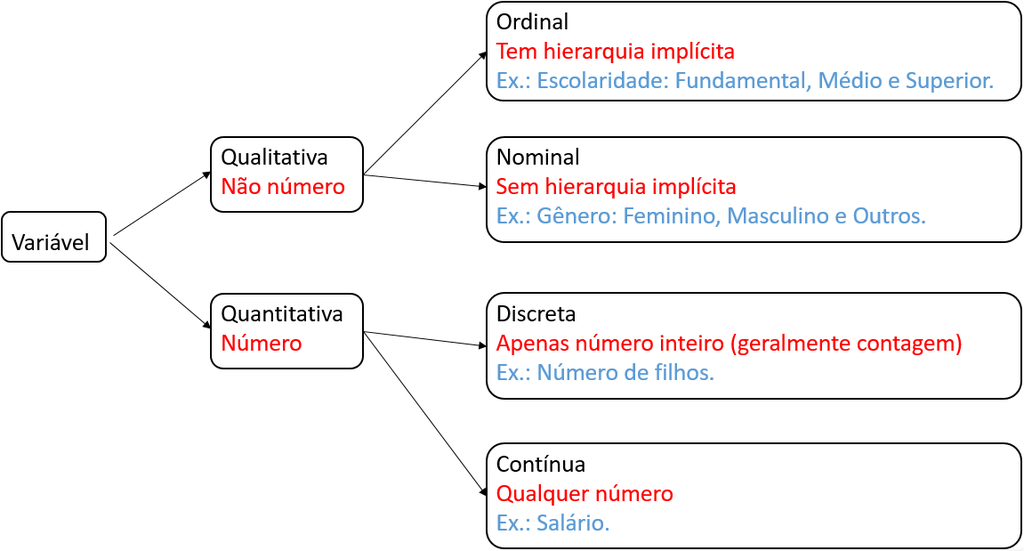

Classificação de variáveis.

## Tabela de frequência – Variável qualitativa

A primeira coisa que fazemos é contar!

| \(X\) | frequência | frequência relativa | porcentagem |
| --- | --- | --- | --- |
| \(B_1\) | \(n_1\) | \(f_1\) | \(100 \cdot f_1\%\) |
| \(B_2\) | \(n_2\) | \(f_2\) | \(100 \cdot f_2\%\) |
| \(\vdots\) | \(\vdots\) | \(\vdots\) | \(\vdots\) |
| \(B_k\) | \(n_k\) | \(f_k\) | \(100 \cdot f_k\%\) |
| Total | \(n\) | \(1\) | \(100\%\) |

Em que \(n\) é o tamanho da amostra.

## Tabela de frequência – Variável qualitativa

A primeira coisa que podemos fazer é construir a tabela de frequência.

- **Pacote:** `tabyl` do `janitor` (instale com o comando `install.packages('janitor')`).
- Parêmetros da função `tabyl`:
  - `dat`: *data frame* ou vetor com os valores da variável que desejamos tabular.
  - `var1`: nome da primeira variável.
  - `var2`: nome da segunda variável (opcional).
- Para mais detalhes, consulte a documentação oficial do *janitor*: [documentação de `tabyl`](https://cran.r-project.org/web/packages/janitor/janitor.pdf).

```r
library(tidyverse)
library(readxl)
library(janitor)
library(dplyr)

df_empresa <- read_xlsx("../data/raw/empresa.xlsx")

tab <- tabyl(df_empresa, escolaridade)
tab <- as_tibble(tab)
tab <- tab |> rename(frequencia = n,
              freq_relativa = percent)
tab <-  tab |>
  add_column(porcentagem = tab$freq_relativa*100)

tab <-  tab |>
  add_case(escolaridade = "Total",
           frequencia = sum(tab$frequencia),
           freq_relativa = sum(tab$freq_relativa),
           porcentagem = sum(tab$porcentagem))
```

| escolaridade | frequencia | freq_relativa | porcentagem |
| --- | --- | --- | --- |
| ensino fundamental | 12 | 0,33 | 33,33 |
| ensino médio | 18 | 0,50 | 50,00 |
| superior | 6 | 0,17 | 16,67 |
| Total | 36 | 1,00 | 100,00 |

## Gráficos no `R`

- **Pacote:** `ggplot2`
- Permite gráficos personalizados com uma sintaxe simples e rápida, e iterativa *por camadas*.
- Começamos com um camada com os dados `ggplot(dados)`, e vamos adicionando as camadas de anotações, e sumários estatísticos.
- Usa a *gramática de gráficos* proposta por Leland Wilkinson: [Grammar of Graphics](https://www.springer.com/gp/book/9780387245447).
- Ideia desta gramática: delinear os atributos estéticos das figuras geométricas (incluindo transformações nos dados e mudança no sistema de coordenadas).
- Para mais detalhes, você pode consultar [`ggplot2`: elegant graphics for data analysis](https://ggplot2-book.org) e [documentação do `ggplot2`](https://ggplot2.tidyverse.org)

## Gráficos no `R`

#### Estrutura básica de `ggplot2`

```r
ggplot(data = <data possible tibble>) +
  <Geom functions>(mapping = aes(<MAPPINGS>)) +
  <outras camadas>
```

Você pode usar diversos temas e extensões que a comunidade cria e criou para melhorar a aparência e facilitar a construção de `ggplot2`.

- Lista com extensões do `ggplot`: [extensões do `ggplots`](https://exts.ggplot2.tidyverse.org/gallery/).

Indicação de extensões:

- Temas adicionais para o pacote `ggplot2`: [`ggthemes`](https://github.com/jrnold/ggthemes).
- Gráfico de matriz de correlação: [`ggcorrplot`](https://rpkgs.datanovia.com/ggcorrplot/).
- Gráfico quantil-quantil: [`qqplotr`](https://github.com/aloy/qqplotr).

## Gráficos no `R`

### Gráfico de barras no `ggplot2`

- **função:** `geom_bar()`. Para porcentagem: `geom_bar(x = <variável no eixo x>, y = ..prop.. * 100)`.
- Argumentos adicionais:
  - **`fill`**: mudar a cor do preenchimento das figuras geométricas.
  - **`color`**: mudar a cor da figura geométrica.
- Rótulos dos eixos
  - **Mudar os rótulos:** `labs(x = <rótulo do eixo x>, y = <rótulo do eixo y>)`.
  - **Trocar o eixo-x pelo eixo-y:** `coord_flip()`.

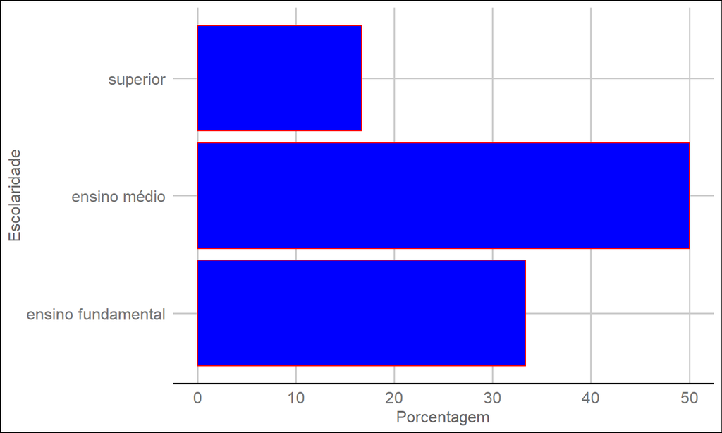

```r
library(ggthemes)
ggplot(df_empresa) +
  geom_bar(mapping = aes(x = escolaridade, y = ..prop.. * 100, group = 1),
  fill = "blue", color = "red") +
  labs(x = "Escolaridade", y = "Porcentagem") +
  theme_gdocs() +
  coord_flip()
```

### Gráfico no `R` com o *simplevis*

- **Pacote:** `gg_bar` do `simplevis` (instale com o comando `install.packages('simplevis')`).
- Parêmetros da função `gg_bar`:
  - `data`: *data frame* da variável tabulada.
  - `x_var`: variável do eixo `x`.
  - `y_var`: variável (numérica) do eixo `y`.
- Para mais detalhes, consulte a documentação oficial do *simplevis*: [documentação de `gg_bar`](https://statisticsnz.github.io/simplevis/articles/simplevis.html).

```r
tab <- tabyl(df_empresa, escolaridade)
tab <- as_tibble(tab)
tab <- tab |> rename(frequencia = n, freq_relativa = percent)
tab <-  tab |>   add_column(porcentagem = tab$freq_relativa*100)
```

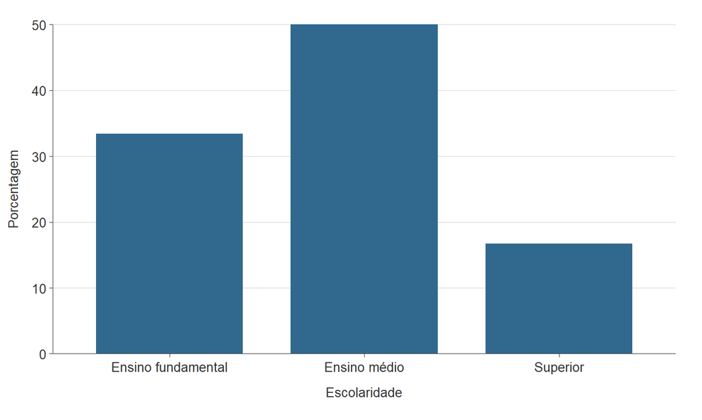

```r
library(simplevis)

gg_bar(tab, x_var = escolaridade, y_var = porcentagem)
```

## Tabela de frequência – Variável quantitativa discreta

A primeira coisa que fazemos é contar!

| \(X\) | frequência | frequência relativa | porcentagem |
| --- | --- | --- | --- |
| \(x_1\) | \(n_1\) | \(f_1\) | \(100\cdot f_1 \%\) |
| \(x_2\) | \(n_2\) | \(f_2\) | \(100\cdot f_2 \%\) |
| \(x_3\) | \(n_3\) | \(f_3\) | \(100\cdot f_3 \%\) |
| \(\vdots\) | \(\vdots\) | \(\vdots\) | \(\vdots\) |
| \(x_k\) | \(n_k\) | \(f_k\) | \(100\cdot f_k \%\) |
| Total | \(n\) | \(1\) | \(100 \%\) |

Em que \(n\) é o tamanho da amostra.

## Tabela de frequência – Variável quantitativa discreta

A primeira coisa que podemos fazer é construir a tabela de frequência.

```r
df_empresa <- read_xlsx("../data/raw/empresa.xlsx")

tab <- tabyl(df_empresa, numero_filhos)
tab <- as_tibble(tab)
tab <- tab |> rename(frequencia = n,
                     freq_relativa = percent)
tab <-  tab |>
  add_column(porcentagem = tab$freq_relativa*100)

tab <- tab |> mutate(numero_filhos = as.character(numero_filhos))

tab <-  tab |>
  add_case(numero_filhos = "Total",
           frequencia = sum(tab$frequencia),
           freq_relativa = sum(tab$freq_relativa),
           porcentagem = sum(tab$porcentagem))
```

| numero_filhos | frequencia | freq_relativa | porcentagem |
| --- | --- | --- | --- |
| 0 | 20 | 0,56 | 55,56 |
| 1 | 5 | 0,14 | 13,89 |
| 2 | 7 | 0,19 | 19,44 |
| 3 | 3 | 0,08 | 8,33 |
| 5 | 1 | 0,03 | 2,78 |
| Total | 36 | 1,00 | 100,00 |

## Gráfico de barras no `R`

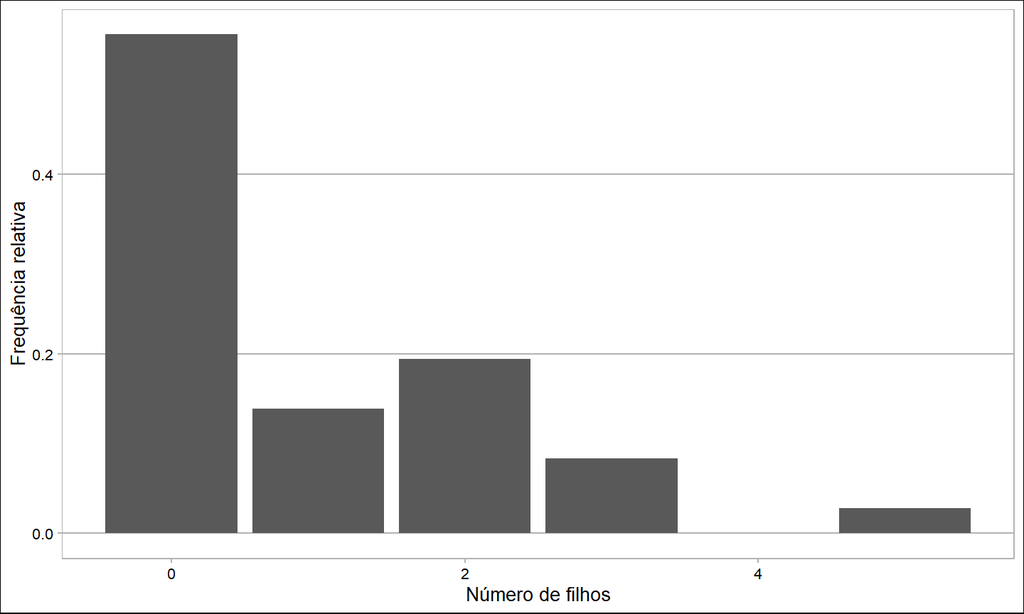

```r
ggplot(df_empresa) +
  geom_bar(aes(x = numero_filhos, y = ..prop.., group = 1)) +
  labs(x = "Número de filhos", y = "Frequência relativa") +
  theme_calc()
```

```r
tab <- tabyl(df_empresa, numero_filhos)
tab <- as_tibble(tab)
tab <- tab |> rename(frequencia = n, freq_relativa = percent)
tab <-  tab |> add_column(porcentagem = tab$freq_relativa*100)
tab <- tab |> mutate(numero_filhos = as.character(numero_filhos))
```

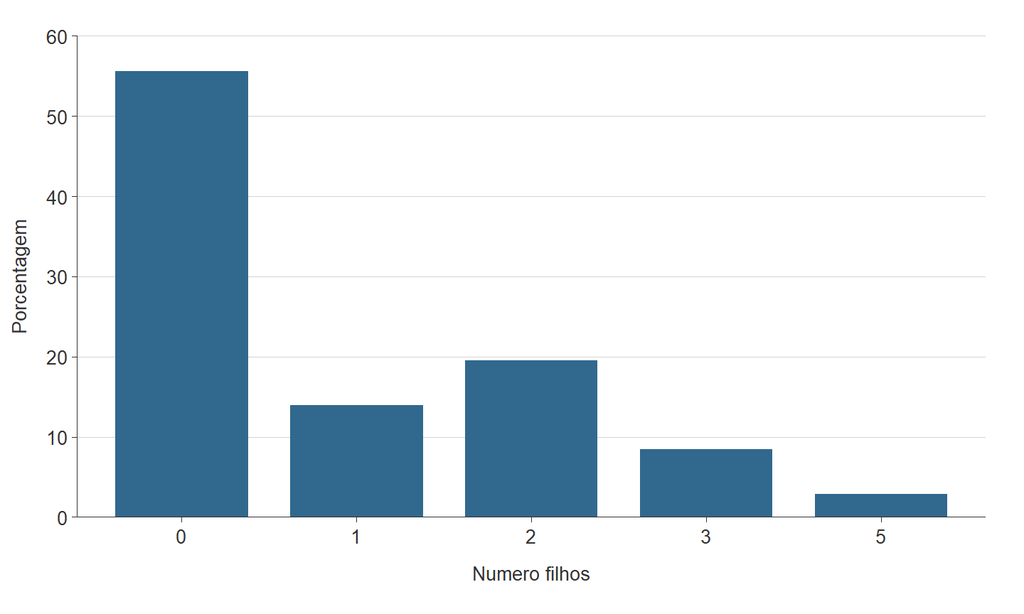

```r
library(simplevis)

gg_bar(tab, x_var = numero_filhos, y_var = porcentagem)
```

## Tabela de frequência – Variável quantitativa contínua

- `X`: variável quantitativa contínua

Tabela de frequências para a variável quantitativa contínua.

| `X` | Frequência | Frequência relativa | Porcentagem |
| --- | --- | --- | --- |
| \([l_0, l_1)\) | \(n_1\) | \(f_1 = \frac{n_1}{n_1 + \dots + n_k}\) | \(p_1 = f_1 \cdot 100\) |
| \([l_1, l_2)\) | \(n_2\) | \(f_2 = \frac{n_2}{n_1 + \dots + n_k}\) | \(p_2 = f_2 \cdot 100\) |
| \(\vdots\) | \(\vdots\) | \(\vdots\) | \(\vdots\) |
| \([l_{k-1}, l_k]\) | \(n_k\) | \(f_k = \frac{n_k}{n_1 + \dots + n_k}\) | \(p_k = f_k \cdot 100\) |

Em que \(\min = l_0 \leq l_1 \leq \cdots \leq l_{k-1} \leq l_k = \max\) (\(\min\) é o menor valor do suporte da variável `X` e \(\max\) é o maior valor do suporte da variável `X`), \(n_i\) é número de valores de `X` entre \(l_{i-1}\) e \(l_i\), e \(l_0, l_1, \dots, l_k\) quebram o suporte da variável `X` (*breakpoints*).

\(l_0, l_1, \cdots, l_k\) são escolhidos de acordo com a teoria por trás da análise de dados (ou pelo regulador).

## Tabela de frequência – Variável quantitativa contínua

```r
df_iris <- read_xlsx("../data/raw/iris.xlsx")

k <- round(1 + log2(nrow(df_iris)))

sep_len_int <- cut(df_iris$Sepal.Length,
    breaks = k, include.lowest = T, right = F)

tab <- tabyl(sep_len_int)
tab <- as_tibble(tab)
tab <- tab |> rename(frequencia = n,
                     freq_relativa = percent)
tab <-  tab |>
  add_column(porcentagem = tab$freq_relativa*100)

tab <-  tab |>
  add_case(sep_len_int = "Total",
           frequencia = sum(tab$frequencia),
           freq_relativa = sum(tab$freq_relativa),
           porcentagem = sum(tab$porcentagem))
```

| sep_len_int | frequencia | freq_relativa | porcentagem |
| --- | --- | --- | --- |
| [4.3,4.75) | 11 | 0,07 | 7,33 |
| [4.75,5.2) | 30 | 0,20 | 20,00 |
| [5.2,5.65) | 24 | 0,16 | 16,00 |
| [5.65,6.1) | 24 | 0,16 | 16,00 |
| [6.1,6.55) | 31 | 0,21 | 20,67 |
| [6.55,7) | 17 | 0,11 | 11,33 |
| [7,7.45) | 7 | 0,05 | 4,67 |
| [7.45,7.9] | 6 | 0,04 | 4,00 |
| Total | 150 | 1,00 | 100,00 |

## Histograma

Para variávieis quantitativas contínuas, geralmente não construímos gráficos de barras, e sim uma figura geométrica chamada de *histograma*.

- O histograma é um gráfico de barras contíguas em que a área de cada barra é igual à frequência relativa.
- Cada faixa de valor \([l_{i-1}, l_{i}), i=1, \dots, n,\) será representada por um barra com área \(f_i, i=1, \dots, n\).
- Como cada barra terá área igual a \(f_i\) e base \(l_i - l_{i-1}\), e a altura de cada barra será \(\frac{f_i}{l_i - l_{i-1}}\).
- \(\frac{f_i}{l_i - l_{i-1}}\) é denominada de densidade de frequência.

## Histograma

[figure not shown]

```r
df_iris <- read_xlsx("../data/raw/iris.xlsx")
k <- round(1 + log2(nrow(df_iris)))

ggplot(df_iris) +
  geom_histogram(aes(x = Sepal.Length, y = ..density..),
                bins = k, fill = "blue") +
  theme_calc() +
  labs(x = "Comprimento de Pétala", y = "Densidade de Frequência")
```

## Medidas resumo (variável quantitativa)

A ideia é encontrar um ou alguns valores que sintetizem todos os valores.

### Medidas de posição (tendência central)

A ideia é encontrar um valor que representa *bem* todos os valores.

- **Média:** \(\overline{x} = \dfrac{x_1+\cdots+x_n}{n}\).
- **Mediana:** valor que divide a sequência ordenada de valores em duas partes iguais.

### Medidas de dispersão

A ideia é medir a homogeneidade dos valores.

- **Variância:** \(s^2 = \dfrac{(x_1 - \overline{X})^2 + \cdots + (x_n - \overline{X})^2}{n-1}\).
- **Desvio padrão:** \(s = \sqrt{s^2}\) (mesma unidade dos dados).
- **Coeficiente de variação** \(cv= \dfrac{s}{\overline{x}} \cdot 100\%\) (adimensional, ou seja, “sem unidade”).

## Medidas resumo: exemplo

Podemos usar a função `summarise` do pacote `dplyr` (incluso no pacote `tidyverse`).

```r
df_empresa |>
  summarise(media = mean(salario),  mediana = median(salario),
            dp = sd(salario), cv = dp / media)
```

```
## # A tibble: 1 × 4
##   media mediana    dp    cv
##   <dbl>   <dbl> <dbl> <dbl>
## 1  11.1    10.2  4.59 0.412
```

## Medidas resumo: exemplo

Podemos usar a função `group_by` para calcular medidas resumo por categorias de uma variável qualitativa.

```r
df_empresa <- read_xlsx("../data/raw/empresa.xlsx")

df_empresa |>
  group_by(escolaridade) |>
  summarise(media = mean(salario), md = median(salario), dp = sd(salario), cv = dp / media) |>
  gt() |>
  tab_header(
    title = "Medidas resumo por escolaridade.",
    subtitle = "Média, mediana, desvio padrão e coeficiente de variação em salários mínimos."
  ) |>
  cols_label(
    escolaridade = "Escolaridade",
    media = "Média salarial",
    md = "Salário mediano",
    dp = "Desvio padrão de salário",
    cv = "Coeficiente de variação"
  ) |>
  fmt_number(
    columns = c(media, md, dp, cv),
    decimals = 2,
    dec_mark = ",",
    sep_mark = "."
  )
```

Medidas resumo por escolaridade.

Média, mediana, desvio padrão e coeficiente de variação em salários mínimos.

| Escolaridade | Média salarial | Salário mediano | Desvio padrão de salário | Coeficiente de variação |
| --- | --- | --- | --- | --- |
| ensino fundamental | 7,84 | 7,12 | 2,96 | 0,38 |
| ensino médio | 11,53 | 10,91 | 3,72 | 0,32 |
| superior | 16,48 | 16,74 | 4,50 | 0,27 |

```r
df_empresa <- read_xlsx("../data/raw/empresa.xlsx")

df_empresa |>
  group_by(escolaridade) |>
  summarise(media = mean(salario), md = median(salario), dp = sd(salario), cv = dp / media) |>
  gt() |>
  tab_header(
    title = "Medidas resumo da variável salário por categoria de escolaridade."
    #subtitle = "Média, desvio padrão, mediana e coeficiente de variação em salários mínimos."
  ) |>
  cols_label(
    escolaridade = "Escolaridade",
    media = "Média",
    md = "Mediana",
    dp = "Desvio padrão",
    cv = "Coeficiente de variação"
  ) |>
  fmt_number(
    columns = c(media, md, dp, cv),
    decimals = 2,
    dec_mark = ",",
    sep_mark = "."
  )
```

Medidas resumo da variável salário por categoria de escolaridade.

| Escolaridade | Média | Mediana | Desvio padrão | Coeficiente de variação |
| --- | --- | --- | --- | --- |
| ensino fundamental | 7,84 | 7,12 | 2,96 | 0,38 |
| ensino médio | 11,53 | 10,91 | 3,72 | 0,32 |
| superior | 16,48 | 16,74 | 4,50 | 0,27 |